# CaliTestScoreAnalysis

Duc-Anh Nguyen

2025-02-08

- lunch: percent qualifying for reduced-price lunch, is a continuous variable ranging from 0 to 100. A higher value of lunch means more students in the school come from low-income families. It serves as a proxy for socioeconomic status (SES) in *education research*.
- income: the median household income in the school district’s area. It serves as an indicator of socioeconomic status (SES) at the *community level*. Higher income levels often correlate with better educational resources, parental involvement, and overall school performance.
- expenditure: expenditure per student. Higher values indicate that the school district spends more per student on education, resources, and infrastructure.
- read: average reading score(scale:0-1000).
- math: average math score per school(scale:0-1000).
- performance: average score of math and reading per school (scale:0-1000).

```r
library(AER)
library(tidyverse)
library(lme4)
data("CASchools")
CASchools |> colnames()
```

```
##  [1] "district"    "school"      "county"      "grades"      "students"
##  [6] "teachers"    "calworks"    "lunch"       "computer"    "expenditure"
## [11] "income"      "english"     "read"        "math"
```

```r
data <-
  CASchools[ ,c("county",
              "lunch",
              "expenditure",
              "income",
              "read",
              "math")]
data$performance <- (data$math + data$read)/2
data |> head()
```

```
##    county   lunch expenditure    income  read  math performance
## 1 Alameda  2.0408    6384.911 22.690001 691.6 690.0      690.80
## 2   Butte 47.9167    5099.381  9.824000 660.5 661.9      661.20
## 3   Butte 76.3226    5501.955  8.978000 636.3 650.9      643.60
## 4   Butte 77.0492    7101.831  8.978000 651.9 643.5      647.70
## 5   Butte 78.4270    5235.988  9.080333 641.8 639.9      640.85
## 6  Fresno 86.9565    5580.147 10.415000 605.7 605.4      605.55
```

```r
dim(data)
```

```
## [1] 420   7
```

```r
skimr::skim(data)
```

Data summary

| Name | data |
| --- | --- |
| Number of rows | 420 |
| Number of columns | 7 |
| _______________________ |  |
| Column type frequency: |  |
| factor | 1 |
| numeric | 6 |
| ________________________ |  |
| Group variables | None |

**Variable type: factor**

| skim_variable | n_missing | complete_rate | ordered | n_unique | top_counts |
| --- | --- | --- | --- | --- | --- |
| county | 0 | 1 | FALSE | 45 | Son: 29, Ker: 27, Los: 27, Tul: 24 |

**Variable type: numeric**

| skim_variable | n_missing | complete_rate | mean | sd | p0 | p25 | p50 | p75 | p100 | hist |
| --- | --- | --- | --- | --- | --- | --- | --- | --- | --- | --- |
| lunch | 0 | 1 | 44.71 | 27.12 | 0.00 | 23.28 | 41.75 | 66.86 | 100.00 | ▆▇▆▅▅ |
| expenditure | 0 | 1 | 5312.41 | 633.94 | 3926.07 | 4906.18 | 5214.52 | 5601.40 | 7711.51 | ▂▇▃▁▁ |
| income | 0 | 1 | 15.32 | 7.23 | 5.34 | 10.64 | 13.73 | 17.63 | 55.33 | ▇▃▁▁▁ |
| read | 0 | 1 | 654.97 | 20.11 | 604.50 | 640.40 | 655.75 | 668.73 | 704.00 | ▂▆▇▆▂ |
| math | 0 | 1 | 653.34 | 18.75 | 605.40 | 639.38 | 652.45 | 665.85 | 709.50 | ▁▆▇▃▁ |
| performance | 0 | 1 | 654.16 | 19.05 | 605.55 | 640.05 | 654.45 | 666.66 | 706.75 | ▂▆▇▅▁ |

```r
length(data$county) == length(unique(data$county))
```

```
## [1] FALSE
```

```r
table(data$county)
```

```
##
##         Alameda           Butte       Calaveras    Contra Costa       El Dorado
##               1               6               1               7              10
##          Fresno           Glenn        Humboldt        Imperial            Inyo
##              12               3              17               6               1
##            Kern           Kings            Lake          Lassen     Los Angeles
##              27               9               2               5              27
##          Madera           Marin       Mendocino          Merced        Monterey
##               5               8               1              11               7
##          Nevada          Orange          Placer       Riverside      Sacramento
##               9              11              11               4               7
##      San Benito  San Bernardino       San Diego     San Joaquin San Luis Obispo
##               3              10              21               6               2
##       San Mateo   Santa Barbara     Santa Clara      Santa Cruz          Shasta
##              17              11              20               7              13
##        Siskiyou          Sonoma      Stanislaus          Sutter          Tehama
##               9              29               7               6               8
##         Trinity          Tulare        Tuolumne         Ventura            Yuba
##               2              24               6               9               2
```

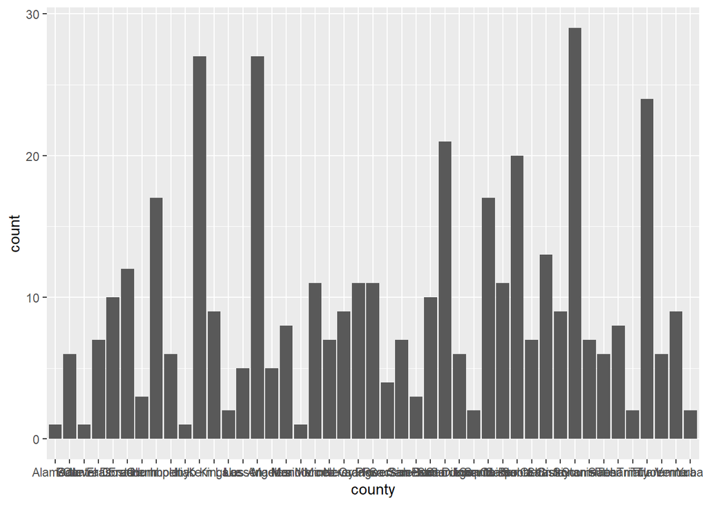

```r
ggplot(aes(county), data = data) + geom_histogram(stat="count")
```

```r
data |> colnames()
```

```
## [1] "county"      "lunch"       "expenditure" "income"      "read"
## [6] "math"        "performance"
```

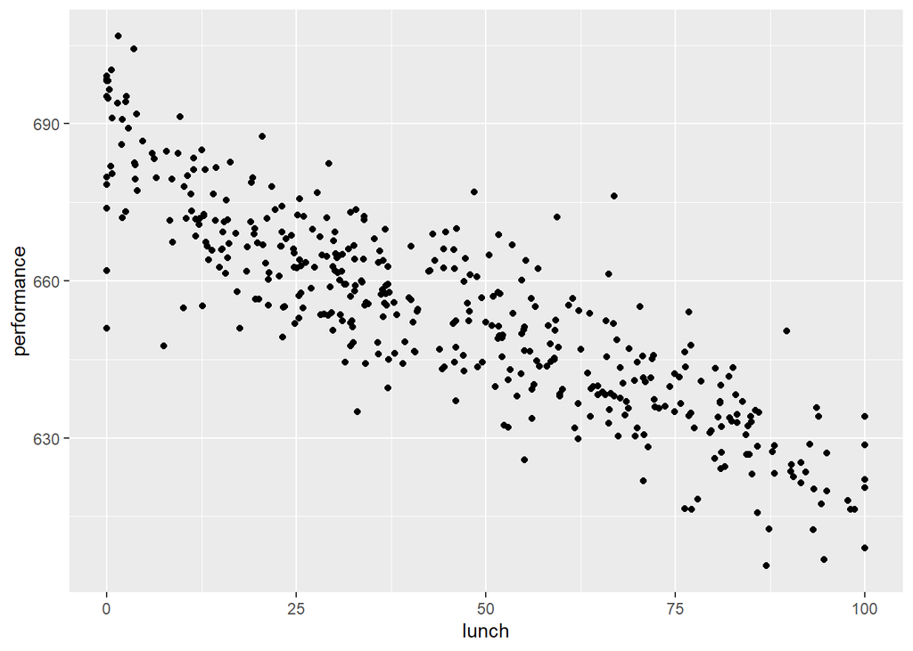

```r
ggplot(aes(lunch, performance), data = data) + geom_point()
```

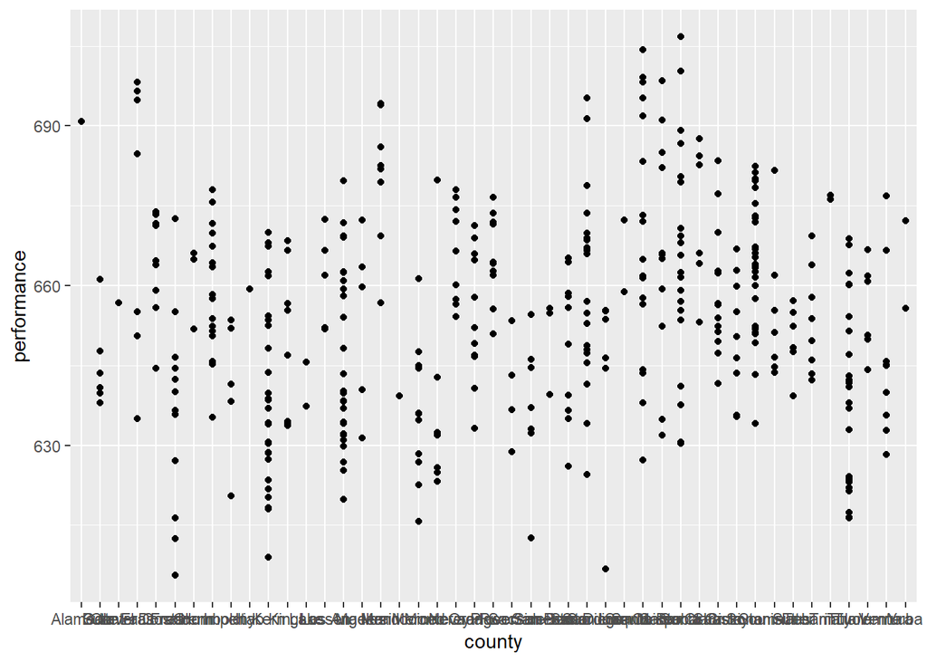

```r
ggplot(aes(county, performance), data = data) + geom_point()
```

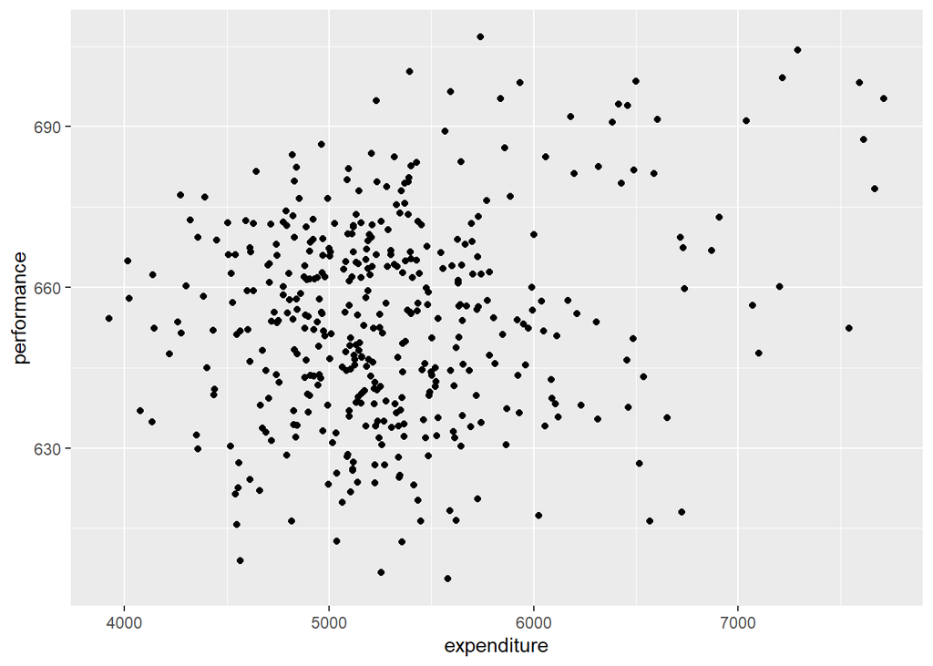

```r
ggplot(aes(expenditure, performance), data = data) + geom_point()
```

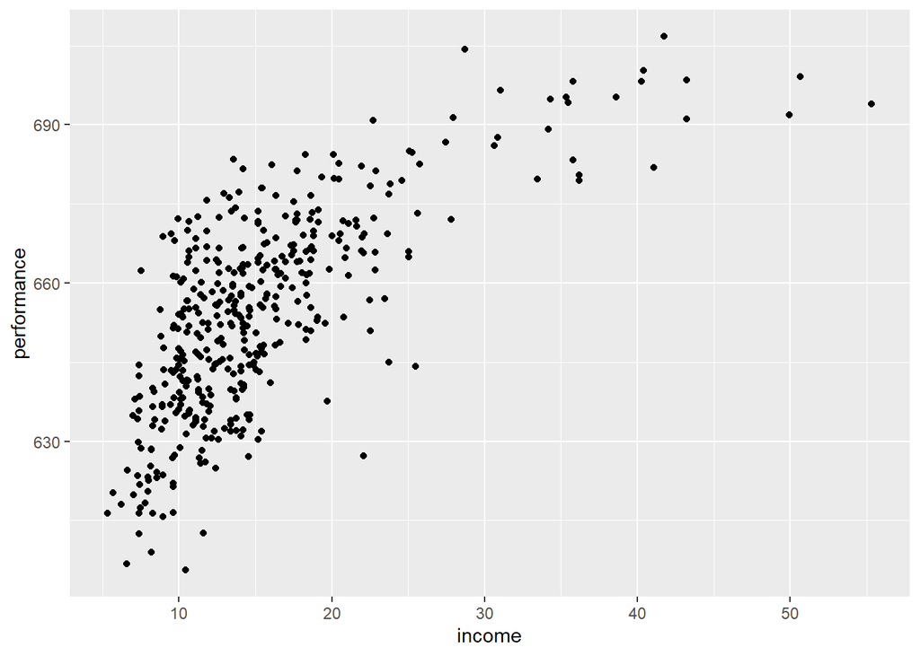

```r
ggplot(aes(income, performance), data = data) + geom_point()
```

From the sample it seems that lunch has a negative correlation with the performance, meanwhile higher incomes tend to correlate with higher perfomance results As results from same state might be somehow correlated, we fit a mixed model.

```r
ri_model <- lmer(performance~lunch + expenditure + income + (1|county), data = data)
ri_model |> summary()
```

```
## Linear mixed model fit by REML ['lmerMod']
## Formula: performance ~ lunch + expenditure + income + (1 | county)
##    Data: data
##
## REML criterion at convergence: 3018.9
##
## Scaled residuals:
##     Min      1Q  Median      3Q     Max
## -3.8967 -0.5595  0.0162  0.5935  2.8659
##
## Random effects:
##  Groups   Name        Variance Std.Dev.
##  county   (Intercept) 18.98    4.357
##  Residual             65.82    8.113
## Number of obs: 420, groups:  county, 45
##
## Fixed effects:
##               Estimate Std. Error t value
## (Intercept)  6.584e+02  3.930e+00 167.537
## lunch       -4.945e-01  2.338e-02 -21.150
## expenditure  1.534e-03  7.642e-04   2.007
## income       6.652e-01  9.804e-02   6.785
##
## Correlation of Fixed Effects:
##             (Intr) lunch  expndt
## lunch       -0.205
## expenditure -0.817 -0.293
## income      -0.161  0.656 -0.373
```

```r
variances <- as.data.frame(VarCorr(ri_model))[,c(1,ncol(as.data.frame(VarCorr(ri_model))))]

(ICC <- (variances$sdcor[1]^2)/((variances$sdcor[1]^2)+ variances$sdcor[2]^2))
```

```
## [1] 0.2238723
```

the marginal correlation between average perfomance scores of schools in the same county is around 22%

From the plot the relationship of the perfomance scores and incomes seems monotonic but non linear, let us fit splines to the model

```r
library(mgcv)
gam_model <-
  gam(performance ~ s(income, bs = "ps", m = c(3, 2)) + lunch + expenditure, data = data)
gam_model |> summary()
```

```
##
## Family: gaussian
## Link function: identity
##
## Formula:
## performance ~ s(income, bs = "ps", m = c(3, 2)) + lunch + expenditure
##
## Parametric coefficients:
##               Estimate Std. Error t value Pr(>|t|)
## (Intercept)  6.651e+02  3.847e+00 172.879  < 2e-16 ***
## lunch       -5.495e-01  2.525e-02 -21.764  < 2e-16 ***
## expenditure  2.567e-03  7.232e-04   3.549 0.000431 ***
## ---
## Signif. codes:  0 '***' 0.001 '**' 0.01 '*' 0.05 '.' 0.1 ' ' 1
##
## Approximate significance of smooth terms:
##             edf Ref.df     F p-value
## s(income) 5.819  6.413 7.272  <2e-16 ***
## ---
## Signif. codes:  0 '***' 0.001 '**' 0.01 '*' 0.05 '.' 0.1 ' ' 1
##
## R-sq.(adj) =  0.794   Deviance explained = 79.8%
## GCV = 76.206  Scale est. = 74.606    n = 420
```

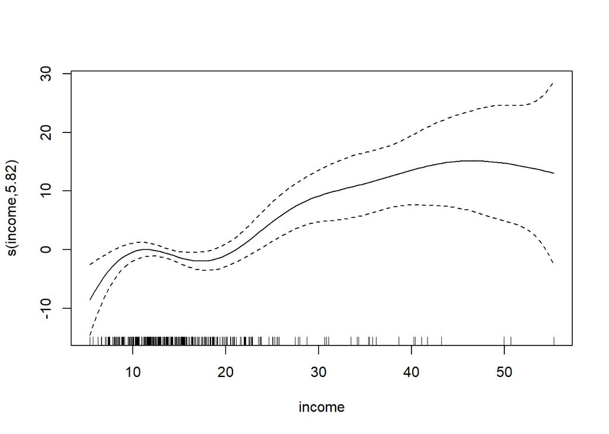

```r
plot(gam_model)
```

Now we want to model the joint distribution of the two average scores math and read at schools. We will use copula for this task.

```r
library(VineCopula)
library(rvinecopulib)
u_cas = cbind.data.frame(
  math = pnorm(data$math, mean = mean(data$math), sd = sd(data$math)),
  read = pnorm(data$read, mean = mean(data$read), sd = sd(data$read))
)

u_cas |> head()
```

```
##          math        read
## 1 0.974686165 0.965745178
## 2 0.675910250 0.608338604
## 3 0.448187287 0.176571172
## 4 0.299853456 0.439318136
## 5 0.236755633 0.256237683
## 6 0.005288599 0.007136979
```

```r
cop_cas = bicop(data = u_cas,
                family_set = "onepar",
                selcrit = "bic")

summary(cop_cas)
```

```
## Bivariate copula fit ('bicop'): family = gaussian, rotation = 0, parameters = 0.92, var_types = c,c
## nobs = 420   logLik = 400.86   npars = 1   AIC = -799.71   BIC = -795.67
```

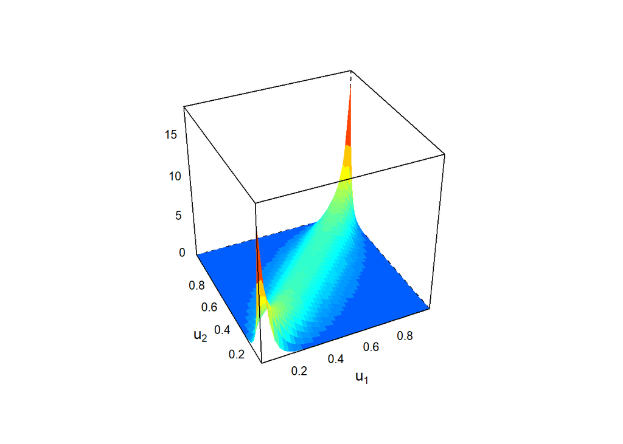

```r
plot(cop_cas)
```